# Clustering Paris neighborhoods from an artistic offer point of view

## 1 Introduction

Many people living in Paris are passionate about art, and indeed Paris offers a large variety of artistic activities : art museums, exhibits, theatre plays, operas, concerts. However, the offer is not the same in all the neighborhoods of Paris. It could be useful to gather neighborhoods which art offer looks alike in clusters for at least two reasons :

- for people who know they like a neighborhood and would like to discover other neighborhoods which offer the same artistic activities.
- for launching new businesses like music venues or art galleries. The clustering helps them identify
  - the neighborhoods where the offer is large, which also means that people go to these neighborhoods because they expect to find these kind of activities.
  - the neighborhoods where the offer is more limited where it could also be interesting to invest and increase the offer and find new customers.

Hence, this project is aimed to cluster neighborhhods using criteria related to art. It aims to answering the question « Which neighborhoods of Paris are similiar from an artistic offer point of view ? »

## 2 Data

### 2.1 Data description

In order to answer to the above question « Which neighborhoods are similiar from an artistic offer point of view », we will use :

1. data from Paris neighborhoods ( https://www.data.gouv.fr/fr/datasets/arrondissements-1/#_ ): Paris geojson file with the coordinates of each neighborhood : its center, and its polygon coordinates. This data will be useful :

   ```
   - to make FourSquare search queries based on the neighborhood coordinates;
   - to represent the neighborhoods clustering in a map.
   ```

2. data from Foursquare :

   ```
   - venue categories identification numbers in order to make queries (https://developer.foursquare.com/docs/build-with-foursquare/categories/).
   - number of museums, art galleries, opera houses, concert halls,  etc for each Paris neighborhood.
   ```

The categories of art venues we will initially use, will be the following :

|  | category | id |
| --- | --- | --- |
| 0 | Art Gallery | 4bf58dd8d48988d1e2931735 |
| 1 | Comedy Club | 4bf58dd8d48988d18e941735 |
| 2 | Concert Hall | 5032792091d4c4b30a586d5c |
| 3 | Exhibit | 56aa371be4b08b9a8d573532 |
| 4 | General Entertainment | 4bf58dd8d48988d1f1931735 |
| 5 | Historic Site | 4deefb944765f83613cdba6e |
| 6 | Movie Theater | 4bf58dd8d48988d17f941735 |
| 7 | Museum | 4bf58dd8d48988d181941735 |
| 8 | Music Venue | 4bf58dd8d48988d1e5931735 |
| 9 | Dance Studio | 4bf58dd8d48988d134941735 |
| 10 | Indie Theater | 4bf58dd8d48988d135941735 |
| 11 | Opera House | 4bf58dd8d48988d136941735 |
| 12 | Theater | 4bf58dd8d48988d137941735 |
| 13 | Public Art | 507c8c4091d498d9fc8c67a9 |
| 14 | Outdoor Sculpture | 52e81612bcbc57f1066b79ed |
| 15 | Street Art | 52e81612bcbc57f1066b79ee |
| 16 | Festival | 5267e4d9e4b0ec79466e48c7 |
| 17 | Music Festival | 5267e4d9e4b0ec79466e48d1 |

The following table gives the neighborhoods in Paris and their centers according to the GEOJSON file.

|  | Neighborhood | Latitude | Longitude |
| --- | --- | --- | --- |
| 0 | 75001 | 48.862563 | 2.336443 |
| 1 | 75002 | 48.868279 | 2.342803 |
| 2 | 75019 | 48.887076 | 2.384821 |
| 3 | 75006 | 48.849130 | 2.332898 |
| 4 | 75010 | 48.876130 | 2.360728 |
| 5 | 75005 | 48.844443 | 2.350715 |
| 6 | 75008 | 48.872721 | 2.312554 |
| 7 | 75013 | 48.828388 | 2.362272 |
| 8 | 75004 | 48.854341 | 2.357630 |
| 9 | 75014 | 48.829245 | 2.326542 |
| 10 | 75003 | 48.862872 | 2.360001 |
| 11 | 75007 | 48.856174 | 2.312188 |
| 12 | 75011 | 48.859059 | 2.380058 |
| 13 | 75009 | 48.877164 | 2.337458 |
| 14 | 75018 | 48.892569 | 2.348161 |
| 15 | 75017 | 48.887327 | 2.306777 |
| 16 | 75020 | 48.863461 | 2.401188 |
| 17 | 75016 | 48.860392 | 2.261971 |
| 18 | 75015 | 48.840085 | 2.292826 |
| 19 | 75012 | 48.834974 | 2.421325 |

### 2.2 Data cleaning

The result table initally contains 1485 results. However, after using the FourSquare search for each neighborhood and each category in the list, we obtain data from Paris but also some other neighborhoods near Paris. We delete these results, as well as the venues which do not have any neighborhood information, representing 317 lines.

We also filter the categories of venues we will use for the clustering in order to keep the most relevent ones. Finally we have 12 categories and the number of venues per category is the following :

[output not shown]

The data that are used for clustering are the following. They represent the number of artistic venues in each neighborhood.

|  | postalcode | Art Gallery | Art Museum | Comedy Club | Concert Hall | Dance Studio | Exhibit | Music Venue | Opera House | Outdoor Sculpture | Public Art | Street Art | Theater |
| --- | --- | --- | --- | --- | --- | --- | --- | --- | --- | --- | --- | --- | --- |
| 1 | 75001 | 4 | 7 | 2 | 1 | 1 | 11 | 3 | 0 | 4 | 0 | 3 | 4 |
| 2 | 75002 | 1 | 0 | 2 | 1 | 1 | 0 | 0 | 0 | 1 | 0 | 4 | 3 |
| 3 | 75003 | 14 | 3 | 2 | 1 | 0 | 0 | 0 | 0 | 0 | 2 | 4 | 2 |
| 4 | 75004 | 8 | 3 | 1 | 2 | 0 | 2 | 1 | 0 | 0 | 2 | 1 | 4 |
| 5 | 75005 | 0 | 1 | 3 | 0 | 0 | 1 | 4 | 0 | 1 | 0 | 3 | 2 |
| 6 | 75006 | 8 | 2 | 2 | 4 | 1 | 2 | 3 | 0 | 2 | 1 | 1 | 4 |
| 7 | 75007 | 9 | 7 | 0 | 2 | 2 | 4 | 2 | 0 | 1 | 1 | 1 | 1 |
| 8 | 75008 | 7 | 3 | 1 | 5 | 2 | 1 | 0 | 0 | 4 | 0 | 0 | 5 |
| 9 | 75009 | 2 | 1 | 4 | 1 | 5 | 2 | 0 | 1 | 0 | 0 | 2 | 7 |
| 10 | 75010 | 3 | 1 | 2 | 3 | 4 | 3 | 3 | 0 | 1 | 1 | 5 | 8 |
| 11 | 75011 | 3 | 2 | 3 | 10 | 1 | 0 | 6 | 0 | 0 | 2 | 1 | 8 |
| 12 | 75012 | 1 | 0 | 1 | 1 | 4 | 1 | 1 | 1 | 0 | 0 | 0 | 5 |
| 13 | 75013 | 3 | 1 | 2 | 3 | 4 | 1 | 1 | 0 | 1 | 2 | 3 | 2 |
| 14 | 75014 | 4 | 1 | 3 | 1 | 4 | 0 | 4 | 0 | 3 | 1 | 1 | 7 |
| 15 | 75015 | 2 | 0 | 2 | 3 | 3 | 1 | 3 | 0 | 3 | 1 | 0 | 6 |
| 16 | 75016 | 2 | 4 | 1 | 3 | 1 | 1 | 2 | 0 | 1 | 0 | 0 | 0 |
| 17 | 75017 | 0 | 0 | 2 | 3 | 1 | 0 | 2 | 0 | 2 | 0 | 1 | 0 |
| 18 | 75018 | 2 | 2 | 4 | 1 | 4 | 0 | 3 | 0 | 4 | 1 | 5 | 11 |
| 19 | 75019 | 0 | 1 | 3 | 4 | 2 | 4 | 4 | 0 | 0 | 0 | 0 | 1 |
| 20 | 75020 | 0 | 0 | 1 | 3 | 5 | 1 | 3 | 0 | 0 | 0 | 5 | 4 |

## 3 Methodology

We will use clustering algorithms in order to find neighborhoods of Paris which artistic offer looks alike.

First we transform data with a MinMax scaler in order for the variables used to be of equal importance. We perform a KMeans algorithm in order to fit the data.

In order to find the optimal number of clusters we use the "Elbow method". As we can see in the following image, the gain in the sum of distances function, decreases more slowly after 6 clusters. Hence, we will perform a KMeans algorithm with 6 clusters.

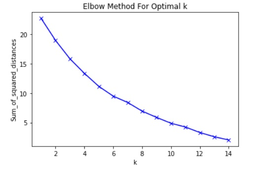

## 4 Results

We obtain the following clusters of Paris neighborhoods represented in a map :

[figure not shown]

Let's have a look at the average number of venues per cluster in order to better understand the clustering.

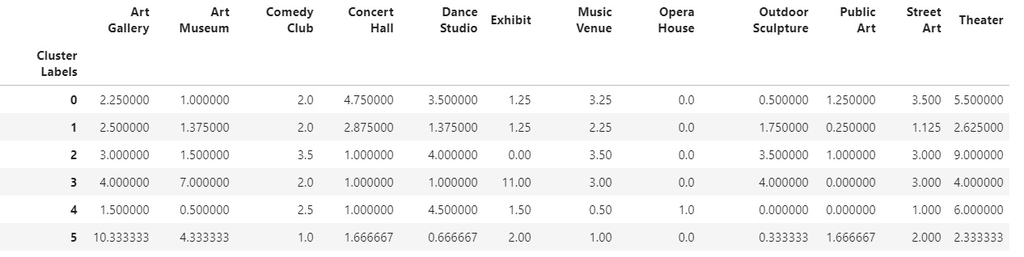

We can observe that :

- **the first cluster (0), in yellow** , is composed of the following neighborhoods : 10, 11, 13, 20. It is the cluster of neighborhoods with the highest number of concert halls, street art and a high number of music venues and theatres.
- **the third cluster (2), in green** , is composed of two neighborhoods : 14 and 18. These neighborhoods present a highest number of theatres, comedy clubs, music venues, and high number of dance studios, and outdoor sculptures and street art.
- **the forth cluster (3), in lightblue** , is composed of only one neighborhood : 1. This neighborhood is the one of art museums and exhibits, and outdoor scluptures. In this neighborhood we have the Louvre, Orangerie, Tuileries gardens.
- **the fifth cluster (4), in darkblue** , is composed of two neighborhoods : 9 and 12. These neighborhoods are the ones where one can find operas and dance studios, and high number of theatres.
- **the sixth cluster (5), in purple** , is composed of three neighborhoods : 3, 4 and 7. These neighborhoods are the ones where one can find the highest number of art galleries and a high number of art museums.
- **the second cluster (1), in lightgreen** , is composed of the other neighborhoods : 2, 5, 6, 8, 15, 16, 17, 19. These neighborhoods present an average number of art venues, but no particular concentration in one venue.

## 5 Discussion

Based on the results, people who know they like a neighborhood or the neighborhood they live in, let's say the 11th ring of Paris, because of the large offer of concerts, can decide to visit or to live in the 10th, 13th and 20th neighborhoods of Paris if this criteria is sufficiently important to them.

An investor who would like to open an art gallery could decide to do so in the 3, 4, 7 neighborhoods that people visit among other things because of the high concentration in art galleries, or to develop art galleries in the 9th or 12th neighborhoods where their number is not high.

However, data used for the study are not exhaustive because of art venues which do not have any associated neighborhood information in FourSquare. Another study should be done with all the data available.

## 6 Conclusion

This study aimed to identify clusters of Paris neighborhoods based on their art offer. Different categories of art categories were chosen, mostly art museums, theatres, opera houses, etc. 6 clusters were identified representing neighborhoods with a high number of particular venues in them.

However, cinemas or other types of artistic places, were not included in the study. It would be interesing to see how they would influence clustering. As discussed in the previous section, all art venues did not include information about the neighborhood they are in. It would thus be of interest to perform the study with those venues in the data set. Choosing other clustering algorithms could also be something of interest to explore